# SuperFarmer - symulacja rozgrywki jednoosobowej

Aleksandra Dąbrowska

Alicja Gosiewska

# 1 Rozważany problem

Zajmujemy sią symulacją gry “SuperFarmer”.

Gracz jest hodowcą zwierząt i pragnie zostać superfarmerem. Gracz zwiększa swój zysk rozmnażając zwierzęta. Może zamieniać wyhodowane zwierzęta na inne, jeąli uzna, że to mu się opłaca. Aby zwyciężyć, musi uzyskać stado złożone, co najmniej z konia, krowy, świni, owcy i królika. Przeszkodą w zdobyciu wszytkich zwierząt są pojawiające się w grze wilki i lisy, które mogą osłabić stado gracza. Początkowo nasz gracz nie ma żadnych zwierząt. Aby zdobyć zwierzęta rzuca dwiema dwunastościennymi kośćmi.

# 2 Opis implementacji gry

Nasz program składa się z 6 funkcji związanych z mechaniką gry, 3 funkcji dotyczących strategii gracza oraz dwóch funkcji rozgrywających odpowiednio jedną lub n partii. Zarówno początkowe stany stada głównego i stada gracza jak i strategia są sparametryzowane i mogą być w prosty sposób modfikowane.

# 3 Funkcje związane z mechaniką gry

Funkcja tworząca struktury gry

```r
przed_wyruszeniem_w_droge_nalezy_zebrac_druzyne <- function(stan_stada, stan_stada_gracza, wyzerowana_tabela){
zwierzeta <- c("krolik","owca","swinia", "krowa", "kon", "maly_pies","duzy_pies")
stado <- stan_stada
names(stado) <- zwierzeta

stado_g1 <- stan_stada_gracza
names(stado_g1) <- zwierzeta

tabela_zmian <- wyzerowana_tabela
names(tabela_zmian) <- zwierzeta

result <- list(stado,stado_g1,tabela_zmian)
return(result)
}
```

Funkcja symulująca rzut kośćmi

```r
rzut <- function(){
d1 <- c("krolik", "krolik", "krolik", "krolik", "krolik", "krolik", "owca", "owca", "owca", "swinia", "krowa", "wilk")
d2 <- c("krolik", "krolik", "krolik", "krolik", "krolik", "krolik", "owca", "owca", "swinia", "swinia", "kon", "lis")

return(c(sample(d1,1),sample(d2,1)))
}
```

Funkcja zwracająca nowe stany stada głównego i stada gracza w zależności od wyniku rzutu kośćmi

```r
przebieg_rzutu_g1 <- function(tabela_zmian, stado, stado_g1, wynik_rzutu){
    if(wynik_rzutu[1] == wynik_rzutu[2])
      tabela_zmian[[wynik_rzutu[1]]] <- floor(2+stado_g1[[wynik_rzutu[1]]]/2) else{
    if(wynik_rzutu[1]=="wilk"){
    ifelse(stado_g1[["duzy_pies"]] > 0, tabela_zmian[["duzy_pies"]] <- -1 , replace(tabela_zmian, tabela_zmian[c(1,2,3,4)],-tabela_zmian[c(1,2,3,4)]))
    }else if(wynik_rzutu[2]=="lis"){
      ifelse(stado_g1[["maly_pies"]] > 0, tabela_zmian[["maly_pies"]] <- -1 ,tabela_zmian[["krolik"]] <- -stado_g1[["krolik"]])
    }else{
      tabela_zmian[[wynik_rzutu[2]]] <- floor((1+stado_g1[[wynik_rzutu[2]]])/2)
      tabela_zmian[[wynik_rzutu[1]]] <- floor((1+stado_g1[[wynik_rzutu[1]]])/2)
  }
  }
  for(i in range(1:5))   tabela_zmian[[i]] <- ifelse(stado[[i]]-tabela_zmian[[i]]<=0,stado[[i]],tabela_zmian[[i]])
  return(tabela_zmian)

}
```

Funkcja zwracająca wartość zwierzęcia wyrażoną w królikach

```r
wartosc <- function(zwierze){
  wart <-switch(zwierze,
                "krolik" = 1,
                "owca" = 6,
                "swinia" = 12,
                "krowa" =  36,
                "kon" = 72,
                "maly_pies" = 6,
                "duzy_pies" = 36)

  return(wart)
}
```

Funkcja dokonująca wymiany bazując na wartościach podanych w zmiennej tabela

```r
dokonanie_wymian <- function(stado, stado_g1,tabela){
    stado_g1 <- stado_g1 + tabela
    stado <- stado - tabela
    return(list(stado_g1, stado))
}
```

Funkcja sprawdzająca, czy tabela spełnia warunki wygranej w grze

```r
czy_wygrana <- function(warunki_wygranej,table){
  for(i in 1:7){
    if(table[[i]]<warunki_wygranej[[i]]) return("Probuj dalej :)")
  }
  return("Jestes zwyciezca!")
}
```

# 4 Funkcje związane ze strategią gracza

Nasza strategia korzysta jedynie z wymiany kilku mniejszych zwierząt na jedno większe.

Wyżej wspomnianą wymianę realizuje następująca funkcja:

```r
kilka_na_jedno <- function(tabela_zmian,tabela_co, na_co){
        cena <- wartosc(na_co)
        kolejnosc <- c("krowa","swinia","owca","krolik","maly_pies","duzy_pies")

        for (i in kolejnosc){
          if(tabela_co[[i]]>0 && wartosc(i)<=cena && cena >0){
          tabela_zmian[[i]] <- -min(floor(cena/wartosc(i)), tabela_co[[i]])
          cena <- cena + tabela_zmian[[i]]*wartosc(i)
          }
        }
        tabela_zmian[[na_co]] <- 1
        ifelse(cena>0, return(FALSE), return(tabela_zmian))
}
```

Wykorzystujemy również funkcję sprawdzającą wartość stada wyrażoną w królikach

```r
wyciag_z_konta <- function(tabela){
  saldo <- 0
  for(i in 1:length(tabela)){
    saldo <- saldo + tabela[[i]]*wartosc(names(tabela)[[i]])
  }
  return(saldo)
}
```

## 4.1 Funkcja strategii gry

Strategia gracza moze być modyfikowana przy użyciu następujących parametrów:

kroliki - minimalna ilość królików, którą gracz zawsze będzie chciał zachować w swoim stadzie

owce - minimalna ilość owiec, którą gracz zawsze będzie chciał zachować w swoim stadzie

duze_psy - minimalna ilość dużych psów, którą gracz zawsze będzie chciał zachować w swoim stadzie

male_psy - minimalna ilość małych psów, którą gracz zawsze będzie chciał zachować w swoim stadzie

```r
strategia_wymian <- function(tabela_zmian,stado,stado_g1,kroliki, owce, duze_psy, male_psy){
  wymiana<-tabela_zmian
  if (stado_g1[["kon"]] >= 2){
    wymiana[1:7]<-c(1,1,1,1,-1,0,0)
    return(wymiana)
  }
  if((wyciag_z_konta(stado_g1[c(1,2,3,4,6,7)])>=72)&&(stado_g1[["kon"]]==1)){
    wymiana <- kilka_na_jedno(tabela_zmian,stado_g1,"kon")
    return(wymiana)
  }
  damy<-c( max(stado_g1[["krolik"]]-kroliki,0),max(stado_g1[["owca"]]-owce,0),0,0,0,max(stado_g1[["maly_pies"]]-male_psy,0),max(stado_g1[["duzy_pies"]]-duze_psy))
  names(damy) <-  c("krolik","owca","swinia", "krowa", "kon", "maly_pies","duzy_pies")
  for(zw in c("kon","maly_pies","duzy_pies","owca")){
    wymiana <-kilka_na_jedno(tabela_zmian,damy,zw)
    param = switch(zw,"kon" = 10,
                      "maly_pies" = male_psy,
                      "duzy_pies" = duze_psy,
                      "owca" = owce)
    if(class(wymiana)=="numeric" && stado_g1[[zw]]< param)  return(wymiana)
  }
  wymiana[1:7]<-c(0,0,0,0,0,0,0)
  return(wymiana)
}
```

# 5 Funkcje rozgrywające grę

```r
gra <- function(stan_stada,stan_stada_gracza,wyzerowana_tabela,kroliki, owce, duze_psy, male_psy,warunki_wygranej){
  licznik <- 0
  struktury <-przed_wyruszeniem_w_droge_nalezy_zebrac_druzyne(stan_stada,stan_stada_gracza,wyzerowana_tabela)
  stado <- struktury[[1]]
  stado_g1 <- struktury[[2]]
  tabela_zmian <- struktury[[3]]
  while (czy_wygrana(warunki_wygranej,stado_g1) != "Jestes zwyciezca!"){
  wymiana<-strategia_wymian(tabela_zmian,stado, stado_g1,kroliki, owce, duze_psy, male_psy)
  wymiany <- dokonanie_wymian(stado, stado_g1,wymiana)
  stado_g1 <- wymiany[[1]]
  stado <- wymiany[[2]]
  efekt_rzutu <- przebieg_rzutu_g1(tabela_zmian,stado,stado_g1,rzut())
  licznik <- licznik+1
  z_rzutu <- dokonanie_wymian(stado,stado_g1,efekt_rzutu)
  stado_g1 <- z_rzutu[[1]]
  stado <- z_rzutu[[2]]
  }
  return(licznik)
}


#dla n partii
partie <- function(n,stan_stada,stan_stada_gracza,wyzerowana_tabela,kroliki, owce, duze_psy, male_psy,warunki_wygranej){
  czasy <- data.frame()
  for (i in 1:n){
    czasy[i,1] <-gra(stan_stada,stan_stada_gracza,wyzerowana_tabela,kroliki, owce, duze_psy, male_psy,warunki_wygranej)
  }
    colnames(czasy)[1] <- "Czas_gry"
  return(czasy)
}
```

# 6 Wywołanie gry dla przykładowych parametrów

```r
stan_stada <- c(60,24,20,12,6,4,2)
stan_stada_gracza <- c(0,0,0,0,0,0,0)
wyzerowana_tabela <- c(0,0,0,0,0,0,0)
warunki_wygranej <- c(1,1,1,1,1,0,0)
names(warunki_wygranej)<-c("krolik","owca","swinia", "krowa", "kon", "maly_pies","duzy_pies")

czasy_3_3_0_0 <- partie(10000,stan_stada,stan_stada_gracza,wyzerowana_tabela,3,3,0,0,warunki_wygranej)
```

# 7 Rozkład czasu gry dla przykładowych parametrów

```r
library(ggplot2)

p<- ggplot(czasy_3_3_0_0,aes(czasy_3_3_0_0))+
    geom_histogram(binwidth = 1, col="black",fill="#9999FF")+
    theme(axis.text = element_text(size = 14),
    panel.grid.major = element_line(colour = "grey40"),
    panel.grid.minor = element_blank(),
    panel.background = element_rect(fill = "white"),
    axis.title=element_text(size=14),
    axis.title.y=element_text(angle=0),
    plot.title=element_text(size=20))+
    xlab("Czas trwania gry")+
    ylab("Liczba gier")+
    labs(title="Rozkład czasu gry")


library(plotly)
f <- list(
  family = "Helvetica",
  size = 20,
  color = "black")
gg <- ggplotly(p)

p %>% ggplotly(originalData = FALSE)
```

[interactive chart not shown]

```r
#dla wszystkich kombinacji parametrow dostajemy sredni czas trwania gry

load("dane_parametry.rda")

library(dplyr)
dane_pogrupowane <- dane_parametry%>%
                    group_by(kroliki, owce, male_psy,duze_psy)%>%
                    summarise(Srednia_dla_strategii=mean(Czas_gry),
                              Odchylenie_stand_dla_strategii=sd(Czas_gry))

dane_pogrupowane$strategia <- paste("kroliki:",dane_pogrupowane$kroliki," owce:",dane_pogrupowane$owce," male psy:", dane_pogrupowane$male_psy," duze psy:", dane_pogrupowane$duze_psy, sep ="")


library(plotly)

plot_ly(dane_pogrupowane,x = ~Srednia_dla_strategii, y = ~Odchylenie_stand_dla_strategii, color = ~as.factor(male_psy), type = 'scatter', mode = "markers", text = ~strategia) %>%
  layout(title = "Scatter plot ze wzgledu na ilosc malych psow" , titlefont=f)
```

[interactive chart not shown]

# 8 Wykresy skrzypcowe dla różnych minimalnych wartości królików

Przy bliższym przyjrzeniu się strategiom o najniższej medianie i odchyleniu standardowym zauważymy, że są tam jedynie strategie, w którcy parametry: male_psy oraz duze_psy były równe 0. Przyjrzyjmy się więc bliżej strategiom jedynie ze względu na króliki. Do zobrazowania tych strategii użyłyśmy wykresów skrzypcowych.

Kropki oznaczają średnie odpowiednich strategii.

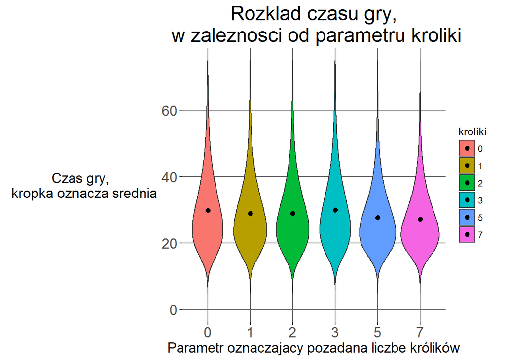

```r
dane_pogrupowane_kroliki <- dane_parametry%>%
                    group_by(kroliki)

ggplot(dane_pogrupowane_kroliki,aes(x= kroliki,y = Czas_gry, fill = kroliki)) + geom_violin(trim = TRUE) + ylim(c(0,75)) + stat_summary(fun.y=mean, geom="point", size=2)+theme(axis.text = element_text(size = 14),
    panel.grid.major = element_line(colour = "grey40"),
    panel.grid.minor = element_blank(),
    panel.background = element_rect(fill = "white"),
    axis.title=element_text(size=14),
    axis.title.y=element_text(angle=0),
    plot.title=element_text(size=20))+
    xlab("Parametr oznaczający pożądaną liczbę królików")+
    ylab("Czas gry, \n kropka oznacza średnią")+
    labs(title="Rozkład czasu gry,\n w zależności od parametru kroliki")
```

Jak możemy zauważyć różnice między strategiami są niewielkie

# 9 ProfileRRRRR

Bardzo przydatnym narzędziem, które odkryłyśmy podczas przygotowań do tej fazy projektu jest profiler. Analizuje on czas wykonania funkcji i zwraca on watości wykonywania poszczególnych operacji. Początkowo nasz kod w wielu miejcach operował ramkami danych (data.frame). Jak się okazało znacząco wydłużają one czas wykonywania kodu. Zamiana ich na wektory pozwoliła skrócić czas wywołania 100 partii gier aż 24 krotnie.

Poniżej przedstawiamy wyniki działania profilera dla starej oraz nowej wersji kodu:

```r
library(knitr)
load("profil.stary.rda")
kable(head(profil_stary[,c(1,3)]),caption="Czasy wywołania funkcji przy używaniu data.frame")
```

Czasy wywolania funkcji przy uzywaniu data.frame

|  | total.time | self.time |
| --- | --- | --- |
| “partie” | 55.64 | 0.00 |
| “gra” | 55.24 | 0.20 |
| “Ops.data.frame” | 34.14 | 1.06 |
| “dokonanie_wymian” | 34.08 | 0.12 |
| “data.frame” | 28.44 | 1.06 |
| “as.data.frame” | 25.32 | 1.70 |

Oraz dla nowej wersji:

```r
Rprof("partie.out")
y <- partie(100,stan_stada,stan_stada_gracza, wyzerowana_tabela,3,3,0,0)  # this is the function to profile
Rprof(NULL)
profil <- summaryRprof("partie.out")
profil_nowy <-as.data.frame(profil$by.total)
```

Czasy wywolania funkcji po zmianie na wektory

|  | total.time | self.time |
| --- | --- | --- |
| “partie” | 2.28 | 0.00 |
| “gra” | 1.36 | 0.10 |
| “print.default” | 0.90 | 0.90 |
| “strategia_wymian” | 0.90 | 0.16 |
| “print” | 0.90 | 0.00 |
| “kilka_na_jedno” | 0.60 | 0.28 |